# Project 3

STA6232 - Stats for Data Science II

Author

Brandy Carr

**This week you again analyze data from the Jackson Heart Study (JHS). You can find the data on Canvas, in the Week 1 module. For full credit, you must include all code chunks and R output backing up your responses.**

## 0

**Import the JHS data.**

```r
library(tidyverse)
JHS <- haven::read_sas("analysis1.sas7bdat")
```

## 1

**1A. Model diabetic status (*Diabetes*; 0=non-diabetic, 1=diabetic) as a function of age (*age*; years), weight (*weight*; kg), hypertension status (*HTN*; 0=normotensive, 1=hypertensive), and fasting HDL categorization (*hdl3cat*; 0=low, 1=normal, 2=high), and the interactions between (1) weight and hypertension and (2) weight and fasting HDL categorization. Remember to report the resulting model.**

```r
# subset data & removed incomplete cases
JHS1 <- JHS %>% select(Diabetes, age, weight, HTN, hdl3cat) %>% na.omit()

# factored variable hdl3cat
JHS1$HDL <- factor(JHS1$hdl3cat, levels=c(0,1,2), labels=c("Low","Normal","High"))

# full model
m1 <- glm(Diabetes ~ age + HDL + HTN + weight + weight:HTN + weight:HDL, data=JHS1, family="binomial"(link="logit"))

# reduced model (intercept only)
reduced <- glm(Diabetes ~ 1, data=JHS1, family="binomial"(link="logit"))

# tests significance of the m1 regression line
anova(reduced, m1, test="LRT")
```

```
Analysis of Deviance Table

Model 1: Diabetes ~ 1
Model 2: Diabetes ~ age + HDL + HTN + weight + weight:HTN + weight:HDL
  Resid. Df Resid. Dev Df Deviance  Pr(>Chi)
1      2454     2221.3
2      2446     1959.4  8   261.91 < 2.2e-16 ***
---
Signif. codes:  0 '***' 0.001 '**' 0.01 '*' 0.05 '.' 0.1 ' ' 1
```

```r
# tests significance of each predictor
car::Anova(m1, type=3)
```

```
Analysis of Deviance Table (Type III tests)

Response: Diabetes
           LR Chisq Df Pr(>Chisq)
age          53.482  1  2.610e-13 ***
HDL           2.166  2  0.3385189
HTN          13.887  1  0.0001941 ***
weight       30.894  1  2.726e-08 ***
HTN:weight    4.272  1  0.0387374 *
HDL:weight    2.936  2  0.2304316
---
Signif. codes:  0 '***' 0.001 '**' 0.01 '*' 0.05 '.' 0.1 ' ' 1
```

```r
# tests significance of all terms (pairwise)
summary(m1)
```

```
Call:
glm(formula = Diabetes ~ age + HDL + HTN + weight + weight:HTN +
    weight:HDL, family = binomial(link = "logit"), data = JHS1)

Coefficients:
                  Estimate Std. Error z value Pr(>|z|)
(Intercept)      -7.403163   0.697099 -10.620  < 2e-16 ***
age               0.042307   0.005913   7.155 8.34e-13 ***
HDLNormal        -0.600167   0.600528  -0.999 0.317601
HDLHigh           0.374930   0.661050   0.567 0.570596
HTN               2.122658   0.573222   3.703 0.000213 ***
weight            0.032120   0.005636   5.700 1.20e-08 ***
HTN:weight       -0.011746   0.005656  -2.077 0.037811 *
HDLNormal:weight  0.002073   0.005909   0.351 0.725697
HDLHigh:weight   -0.009787   0.006967  -1.405 0.160092
---
Signif. codes:  0 '***' 0.001 '**' 0.01 '*' 0.05 '.' 0.1 ' ' 1

(Dispersion parameter for binomial family taken to be 1)

    Null deviance: 2221.4  on 2454  degrees of freedom
Residual deviance: 1959.4  on 2446  degrees of freedom
AIC: 1977.4

Number of Fisher Scoring iterations: 5
```

`FULL MODEL`

`COMMENTS`

The full model predicts Diabetes significantly better than the intercept only (reduced) model.

HDL is NOT a significant predictor of Diabetes & neither is it’s interaction with weight.

**1B. Perform the appropriate hypothesis test to determine if the interaction between weight and hypertension status is significant. Test at the $\alpha=0.05$ level.**

```r
# binary X continuous
round(summary(m1)$coeff[drop=F, "HTN:weight", c(3,4)], 4)
```

```
           z value Pr(>|z|)
HTN:weight -2.0769   0.0378
```

`Hypotheses`

$H_{0}$ : $\beta_{HTN:weight} = 0$

$H_{1}$ : $\beta_{HTN:weight} \ne 0$

`Test Statistic`

$z_{0} = -2.0769$

`P-Value`

$p < 0.0378$

`Rejection Region`

Reject $H_{0}$ if $p < \alpha;$ $\phantom0 \alpha = 0.05$

`Conclusion`

Reject $H_{0}.$

There is sufficient evidence to suggest that the interaction between hypertension status and weight (*HTN:weight*) significantly predicts *Diabetes*.

**1C. Perform the appropriate hypothesis test to determine if the interaction between fasting HDL categorization and weight (*HDL:weight*)is significant. Test at the $\alpha=0.05$ level.**

```r
# categotical(c=3) X continuous
round(car::Anova(m1, type=3)[drop=F, "HDL:weight",], 4)
```

```
Analysis of Deviance Table (Type III tests)

Response: Diabetes
           LR Chisq Df Pr(>Chisq)
HDL:weight   2.9356  2     0.2304
```

`Hypotheses`

$H_{0}$ : $\beta_{HDL_{norm}:weight} = \beta_{HDL_{high}:weight} = 0$

$H_{1}$ : at least one $\beta_{i} \ne 0$

`Test Statistic`

$\chi^2 = 2.9360$

`P-Value`

$p = 0.2304$

`Rejection Region`

Reject $H_{0}$ if $p < \alpha;$ $\phantom0 \alpha = 0.05$

`Conclusion`

Fail to reject $H_{0}.$

There is NOT sufficient evidence to suggest that the relationship between *Diabetes* and *weight* depends on fasting HDL categorization (*HDL*).

**1D. Create the following models (i.e., plug in the following values and algebraically simplify): (1) weight of 70 kg, (2) weight of 90 kg, and (3) weight of 110 kg. Remember to report the resulting models.**

$\small{\text{***Displaying rounded coefficients in models below, but used un-rounded values for calculations on the back end}}$

`weight = 70kg`

$$\small{ln \left( \frac{\pi}{1-\pi} \right) = -7.4 + 0.04(age) - 0.6(HDL_{norm}) + 0.36(HDL_{high}) + 2.12(HTN) + 2.25 - 0.82(HTN) + 0.15(HDL_{norm}) - 0.69(HDL_{high})}$$

$$\small{ln \left( \frac{\pi}{1-\pi} \right) = -5.155 + 0.042(age) - 0.455(HDL_{norm}) - 0.310(HDL_{high}) + 1.300(HTN)} \tag{1}$$

`weight = 90kg`

$$\small{ln \left( \frac{\pi}{1-\pi} \right) = -7.4 + 0.04(age) - 0.6(HDL_{norm}) + 0.36(HDL_{high}) + 2.12(HTN) + 2.89 - 1.06(HTN) + 0.19(HDL_{norm}) - 0.88(HDL_{high})}$$

$$\small{ln \left( \frac{\pi}{1-\pi} \right) = -4.512 + 0.042(age) - 0.414(HDL_{norm}) - 0.506(HDL_{high}) + 1.065(HTN)} \tag{2}$$

`weight = 110kg`

$$\small{ln \left( \frac{\pi}{1-\pi} \right) = -7.4 + 0.04(age) - 0.6(HDL_{norm}) + 0.36(HDL_{high}) + 2.12(HTN) + 3.54 - 1.29(HTN) + 0.23(HDL_{norm}) - 1.08(HDL_{high})}$$

$$\small{ln \left( \frac{\pi}{1-\pi} \right) = -3.870 + 0.042(age) - 0.372(HDL_{norm}) - 0.702(HDL_{high}) + 0.831(HTN)} \tag{3}$$

**1E. Find the odds ratios for the models in 1d.**

```r
Models = data.frame(weight_70kg = c(-5.115, 0.042, -0.455, -0.310, 1.300),
                    weight_90kg = c(-4.512, 0.042, -0.414, -0.506, 1.065),
                    weight_110kg = c(-3.870, 0.042, -0.372, -0.702, 0.831))
rownames(Models) = c("Intercept", "age", "HDLnorm", "HDLhigh", "HTN")
Models
```

```
          weight_70kg weight_90kg weight_110kg
Intercept      -5.115      -4.512       -3.870
age             0.042       0.042        0.042
HDLnorm        -0.455      -0.414       -0.372
HDLhigh        -0.310      -0.506       -0.702
HTN             1.300       1.065        0.831
```

```r
# Model 1: weight = 70kg
Models[-1,] %>%
  select(weight_70kg) %>%
  mutate(OddsRatio = round(exp(weight_70kg), 1),
         "OddsRatio%" = paste0(round(100*(exp(weight_70kg)-1), 1), "%"))
```

```
        weight_70kg OddsRatio OddsRatio%
age           0.042       1.0       4.3%
HDLnorm      -0.455       0.6     -36.6%
HDLhigh      -0.310       0.7     -26.7%
HTN           1.300       3.7     266.9%
```

```r
# Model 2: weight = 90kg
Models[-1,] %>%
  select(weight_90kg) %>%
  mutate(OddsRatio = round(exp(weight_90kg), 1),
         "OddsRatio%" = paste0(round(100*(exp(weight_90kg)-1), 1), "%"))
```

```
        weight_90kg OddsRatio OddsRatio%
age           0.042       1.0       4.3%
HDLnorm      -0.414       0.7     -33.9%
HDLhigh      -0.506       0.6     -39.7%
HTN           1.065       2.9     190.1%
```

```r
# Model 3: weight = 110kg
Models[-1,] %>%
  select(weight_110kg) %>%
  mutate(OddsRatio = round(exp(weight_110kg), 1),
         "OddsRatio%" = paste0(round(100*(exp(weight_110kg)-1), 1), "%"))
```

```
        weight_110kg OddsRatio OddsRatio%
age            0.042       1.0       4.3%
HDLnorm       -0.372       0.7     -31.1%
HDLhigh       -0.702       0.5     -50.4%
HTN            0.831       2.3     129.6%
```

**1F. Provide brief interpretations of the odds ratios found in one model (your choice) in 1e.**

Regardless of weight:

- For every 1 year increase in age, the odds of having Diabetes increases by 4.3%.

For participants who weighed 70 kg (see Equation 1 for the model):

- The odds of having Diabetes is 3.7 times higher for hypertensive participants than it is for normotensive participants.
- As compared to a fasting HDL categorization of low:
  - The odds of having Diabetes for a fasting HDL categorization of normal are decreased by 36.6%.
  - The odds of having Diabetes for a fasting HDL categorization of high are decreased by 26.7%.

For participants who weighed 90 kg (see Equation 2 for the model):

- The odds of having Diabetes is 2.9 times higher for hypertensive participants than it is for normotensive participants.
- As compared to a fasting HDL categorization of low:
  - The odds of having Diabetes for a fasting HDL categorization of normal are decreased by 33.9%.
  - The odds of having Diabetes for a fasting HDL categorization of high are decreased by 39.7%.

For participants who weighed 110 kg (see Equation 3 for the model):

- The odds of having Diabetes is 2.3 times higher for hypertensive participants than it is for normotensive participants.
- As compared to a fasting HDL categorization of low:
  - The odds of having Diabetes for a fasting HDL categorization of normal are decreased by 31.1%.
  - The odds of having Diabetes for a fasting HDL categorization of high are decreased by 50.4%.

**1G. Construct an appropriate data visualization to help with explaining the model results. Diabetic status should be on the y-axis, age should be on the x-axis, and use the regression lines constructed in 1d.**

```r
library(fastDummies)
JHS1 <- JHS1 %>%
  dummy_cols(select_columns = c("HDL")) %>%
  mutate(p_70kg = exp(Models[1,1] + Models[2,1]*age + Models[3,1]*HDL_norm + Models[4,1]*HDL_high + Models[5,1]*HTN) /
           (1 + exp(Models[1,1] + Models[2,1]*age + Models[3,1]*HDL_norm + Models[4,1]*HDL_high + Models[5,1]*HTN)),
         p_90kg = exp(Models[1,2] + Models[2,2]*age + Models[3,2]*HDL_norm + Models[4,2]*HDL_high + Models[5,2]*HTN) /
           (1 + exp(Models[1,2] + Models[2,2]*age + Models[3,2]*HDL_norm + Models[4,2]*HDL_high + Models[5,2]*HTN)),
         p_110kg = exp(Models[1,3] + Models[2,3]*age + Models[3,3]*HDL_norm + Models[4,3]*HDL_high + Models[5,3]*HTN) /
           (1 + exp(Models[1,3] + Models[2,3]*age + Models[3,3]*HDL_norm + Models[4,3]*HDL_high + Models[5,3]*HTN)))

JHS1$HTN2 <- factor(JHS1$HTN, levels=c(0,1), labels=c("Normotensive", "Hypertensive"))
JHS1$HDL2 <- factor(JHS1$hdl3cat, levels=c(0,1,2), labels=c("Low HDL", "Normal HDL", "High HDL"))

JHS1 %>%
  group_by(HTN2, HDL2) %>%
  ggplot(aes(x=age, y=Diabetes)) +
  geom_point(alpha=0.2, size=1) +
  geom_line(aes(y=p_70kg), color = "#00BBA0", linewidth = 0.6, linetype = 1) +
  geom_line(aes(y=p_90kg), color = "#FA962D", linewidth = 0.6, linetype = 1) +
  geom_line(aes(y=p_110kg), color = "#C71585", linewidth = 0.6, linetype = 1) +
  labs(x = "Age", y = "Probability of Diabetes") +
  facet_grid(HTN2 ~ HDL2) +
  theme_bw(base_size = 6.5) +
  theme(title=element_text(face="bold"), legend.position="none")
```

[output not shown]

[output not shown]

[output not shown]

## 2

**2A. Using ordinal logistic regression, model diabetic status (*diab3cat*; 0=non-diabetic, 1=pre-diabetic, 2=diabetic) as a function of age (*age*; years), weight (*weight*; kg), hypertension status (*HTN*; 0=normotensive, 1=hypertensive), and fasting HDL categorization (*hdl3cat*; 0=low, 1=normal, 2=high). Remember to report the resulting model.**

```r
# subset data & removed incomplete cases
JHS2 <- JHS %>% select(diab3cat, age, weight, HTN, hdl3cat) %>% na.omit()

# factored variables diab3cat, HTN, & hdl3cat
JHS2$Diabetes <- factor(JHS2$diab3cat, levels=c(0,1,2), labels=c("Non-Diabetic","Pre-Diabetic","Diabetic"))
JHS2$HTN <- factor(JHS2$HTN, levels=c(0,1), labels=c("Normotensive","Hypertensive"))
JHS2$HDL <- factor(JHS2$hdl3cat, levels=c(0,1,2), labels=c("Low","Normal","High"))

# ordinal logistic regression model
m2 <- MASS::polr(Diabetes ~ age + HDL + HTN + weight, data=JHS2, Hess=T)
summary(m2)
```

```
Call:
MASS::polr(formula = Diabetes ~ age + HDL + HTN + weight, data = JHS2,
    Hess = T)

Coefficients:
                   Value Std. Error t value
age              0.05135   0.004046  12.690
HDLNormal       -0.29634   0.091990  -3.221
HDLHigh         -0.58726   0.107887  -5.443
HTNHypertensive  0.63215   0.088765   7.122
weight           0.02463   0.002077  11.855

Intercepts:
                          Value   Std. Error t value
Non-Diabetic|Pre-Diabetic  4.9953  0.3225    15.4876
Pre-Diabetic|Diabetic      6.9604  0.3377    20.6094

Residual Deviance: 4497.656
AIC: 4511.656
```

`MODELS`

logit$(P[Y\le \text{Non-Diabetic}])$ = 4.995 + 0.051(age) - 0.296(HDLNormal) - 0.587(HDLHigh) + 0.632(Hypertensive) + 0.025(weight)

logit$(P[Y\le \text{Pre-Diabetic}])$ = 6.960 + 0.051(age) - 0.296(HDLNormal) - 0.587(HDLHigh) + 0.632(Hypertensive) + 0.025(weight)

**2B. Which predictors, if any, are significant predictors of diabetic status?**

```r
car::Anova(m2, type = 3)
```

```
Analysis of Deviance Table (Type III tests)

Response: Diabetes
       LR Chisq Df Pr(>Chisq)
age     171.002  1  < 2.2e-16 ***
HDL      30.810  2  2.040e-07 ***
HTN      50.964  1  9.407e-13 ***
weight  147.099  1  < 2.2e-16 ***
---
Signif. codes:  0 '***' 0.001 '**' 0.01 '*' 0.05 '.' 0.1 ' ' 1
```

All predictors are significant predictors of diabetic status.

**2C. Find the odds ratios and corresponding 95% CIs for the predictors.**

```r
OR = round(exp(coefficients(m2)), 2)
cbind(OR, round(exp(confint(m2)), 2))
```

```
                  OR 2.5 % 97.5 %
age             1.05  1.04   1.06
HDLNormal       0.74  0.62   0.89
HDLHigh         0.56  0.45   0.69
HTNHypertensive 1.88  1.58   2.24
weight          1.02  1.02   1.03
```

**2D. Provide brief interpretations of the odds ratios found in 2c.**

`HDL`

For any fixed response, the estimated odds of those with $\text{Normal HDL}$ is in the $\text{Non-Diabetic}$ direction rather than the $\text{Diabetic}$ direction are [$e^{-0.2963}$] = 0.74 times the estimated odds of those with $\text{Low HDL}$. This is a 26% decrease in odds as compared to those with $\text{Low HDL}$.

For any fixed response, the estimated odds of those with $\text{High HDL}$ is in the $\text{Non-Diabetic}$ direction rather than the $\text{Diabetic}$ direction are [$e^{-0.5873}$] = 0.56 times the estimated odds of those with $\text{Low HDL}$. This is a 44% decrease in odds as compared to those with $\text{Low HDL}$.

`weight`

For a 1 kg increase in $\text{weight}$, the odds in favor of those who are $\text{Pre-Diabetic}$ or lower, as compared to those who are $\text{Diabetic}$, are increased by [$100*(e^{0.0246}-1)$] = 2.5%.

## 3

**3A. Using nominal/multinomial logistic regression, model diabetic status (*diab3cat*; 0=non-diabetic, 1=pre-diabetic, 2=diabetic) as a function of age (*age*; years), weight (*weight*; kg), hypertension status (*HTN*; 0=normotensive, 1=hypertensive), and fasting HDL categorization (*hdl3cat*; 0=low, 1=normal, 2=high). Remember to report the resulting model.**

```r
# subset data & removed incomplete cases
JHS3 <- JHS %>% select(diab3cat, age, weight, HTN, hdl3cat) %>% na.omit()

# factored variables diab3cat, HTN, & hdl3cat
JHS3$Diabetes <- factor(JHS3$diab3cat, levels=c(0,1,2), labels=c("Non-Diabetic","Pre-Diabetic","Diabetic"))
JHS3$HTN <- factor(JHS3$HTN, levels=c(0,1), labels=c("Normotensive","Hypertensive"))
JHS3$HDL <- factor(JHS3$hdl3cat, levels=c(0,1,2), labels=c("Low","Normal","High"))

# nominal logistic regression model
m3 <- nnet::multinom(Diabetes ~ age + HDL + HTN + weight, data=JHS3)
summary(m3, digits=3)
```

```
Call:
nnet::multinom(formula = Diabetes ~ age + HDL + HTN + weight,
    data = JHS3)

Coefficients:
             (Intercept)    age HDLNormal HDLHigh HTNHypertensive weight
Pre-Diabetic       -5.10 0.0520    -0.176  -0.514           0.312 0.0227
Diabetic           -8.34 0.0688    -0.493  -0.774           1.117 0.0346

Std. Errors:
             (Intercept)     age HDLNormal HDLHigh HTNHypertensive  weight
Pre-Diabetic       0.383 0.00479     0.110   0.128           0.103 0.00255
Diabetic           0.542 0.00655     0.144   0.167           0.146 0.00321

Residual Deviance: 4478.623
AIC: 4502.623
```

`MODELS`

$ln(\frac{\pi_{\small{Pre-Diabetic}}}{\pi_{\small{Non-Diabetic}}}) \text{ = -5.10 + 0.052(age) - 0.176(HDL}_{\small{Normal}}\text{) - 0.514(HDL}_{\small{High}}\text{) + 0.312(HTN}_{\small{Hypertensive}}\text{) + 0.023(weight)}$

$ln(\frac{\pi_{\small{Diabetic}}}{\pi_{\small{Non-Diabetic}}}) \text{ = -8.34 + 0.069(age) - 0.493(HDL}_{\small{Normal}}\text{) - 0.774(HDL}_{\small{High}}\text{) + 1.117(HTN}_{\small{Hypertensive}}\text{) + 0.035(weight)}$

**3B. Which predictors, if any, are significant predictors of diabetic status?**

```r
# global significance
car::Anova(m3, type = 3)
```

```
Analysis of Deviance Table (Type III tests)

Response: Diabetes
       LR Chisq Df Pr(>Chisq)
age     179.513  2  < 2.2e-16 ***
HDL      30.788  4  3.381e-06 ***
HTN      62.579  2  2.577e-14 ***
weight  148.107  2  < 2.2e-16 ***
---
Signif. codes:  0 '***' 0.001 '**' 0.01 '*' 0.05 '.' 0.1 ' ' 1
```

```r
# term significance (by model)
z <- summary(m3)$coefficients/summary(m3)$standard.errors
pval <- t((1 - pnorm(abs(z)))*2)

round(pval, 4) %>%
  as.data.frame() %>%
  mutate(TERM = rownames(pval)) %>%
  pivot_longer(cols = !TERM, names_to = "MODEL", values_to = "PVAL") %>%
  mutate(' ' = ifelse(PVAL < 0.001, '***',
                      ifelse(PVAL < 0.01, '**',
                             ifelse(PVAL < 0.05, '*','')))) %>%
  as.data.frame() %>%
  relocate(MODEL, .before = TERM) %>%
  arrange(MODEL)
```

```
          MODEL            TERM   PVAL
1      Diabetic     (Intercept) 0.0000 ***
2      Diabetic             age 0.0000 ***
3      Diabetic       HDLNormal 0.0006 ***
4      Diabetic         HDLHigh 0.0000 ***
5      Diabetic HTNHypertensive 0.0000 ***
6      Diabetic          weight 0.0000 ***
7  Pre-Diabetic     (Intercept) 0.0000 ***
8  Pre-Diabetic             age 0.0000 ***
9  Pre-Diabetic       HDLNormal 0.1093
10 Pre-Diabetic         HDLHigh 0.0001 ***
11 Pre-Diabetic HTNHypertensive 0.0024  **
12 Pre-Diabetic          weight 0.0000 ***
```

`Results`

Globally, all variables are significant predictors of diabetic status (p<0.05 $\forall$ vars).

This holds true $\forall$ vars when comparing $\text{Diabetic}$ to $\text{Non-Diabetic}$.

This also holds true for vars: age, HTN, and weight, when comparing $\text{Pre-Diabetic}$ to $\text{Non-Diabetic}$.

It does NOT hold true for all terms of variable HDL when comparing $\text{Pre-Diabetic}$ to $\text{Non-Diabetic}$.

- HDLNormal is NOT significant (p=0.11)
- HDLHigh is significant (p<0.05)

**3C. Find the odds ratios and corresponding 95% CIs for the predictors.**

```r
# odds ratios
round(exp(coefficients(m3)), 2)
```

```
             (Intercept)  age HDLNormal HDLHigh HTNHypertensive weight
Pre-Diabetic        0.01 1.05      0.84    0.60            1.37   1.02
Diabetic            0.00 1.07      0.61    0.46            3.06   1.04
```

```r
# 95% CIs
round(exp(confint(m3)), 2)
```

```
, , Pre-Diabetic

                2.5 % 97.5 %
(Intercept)      0.00   0.01
age              1.04   1.06
HDLNormal        0.68   1.04
HDLHigh          0.47   0.77
HTNHypertensive  1.12   1.67
weight           1.02   1.03

, , Diabetic

                2.5 % 97.5 %
(Intercept)      0.00   0.00
age              1.06   1.09
HDLNormal        0.46   0.81
HDLHigh          0.33   0.64
HTNHypertensive  2.30   4.07
weight           1.03   1.04
```

**3D. Provide brief interpretations of the odds ratios found in 3c.**

`Continuous Predictors`

age

- For a one year increase in age, the odds of being Pre-Diabetic, as compared to being Non-Diabetic, are increased by 5%.
- For a one year increase in age, the odds of being Diabetic, as compared to being Non-Diabetic, are increased by 7%.

weight

- For a 1 kg increase in weight, the odds of being Pre-Diabetic, as compared to being Non-Diabetic, are increased by 2%.
- For a 1 kg increase in weight, the odds of being Diabetic, as compared to being Non-Diabetic, are increased by 4%.

`Categorical Predictors`

HTN

- As compared to someone who is Normotensive, someone who is Hypertensive has a 37% increase in the odds of being Pre-Diabetic as compared to being Non-Diabetic.
- As compared to someone who is Normotensive, someone who is Hypertensive has a 206% increase in the odds of being Diabetic as compared to being Non-Diabetic.

HDL

- As compared to someone with Low HDL, someone with Normal HDL has a 16% decrease in the odds of being Pre-Diabetic as compared to being Non-Diabetic.
- As compared to someone with Low HDL, someone with Normal HDL has a 39% decrease in the odds of being Diabetic as compared to being Non-Diabetic.
- As compared to someone with Low HDL, someone with High HDL has a 40% decrease in the odds of being Pre-Diabetic as compared to being Non-Diabetic.
- As compared to someone with Low HDL, someone with High HDL has a 54% decrease in the odds of being Diabetic as compared to being Non-Diabetic.

## 4

**4A. Consider the proportional odds assumption for ordinal logistic regression. Explain the proportional odds assumption to your supervisor, who is not a statistician or data scientist.**

Ordinal logistic regression is used for predicting outcome variables with more than 1 level. It assumes that the change in odds is consistent when moving between the levels. If the assumption holds true, the change in odds is not affected by the outcome levels. The means that the slopes will be the same for each outcome level making modeling and analysis much simpler, allowing us to make more general statements about the predictor variables affect on the overall odds. When plotting prediction lines, they should be parallel at each outcome level. If the assumption doesn’t hold true, it suggests that several predictors may be involved at different outcome levels, the slopes will be different for each level. When plotting prediction lines, they will not be parallel at each outcome level. When the assumption is not met, nominal logistic regression must be used instead.

**4B. Use the appropriate hypothesis test to determine if we should use model 2a or model 3a when reporting on diabetic status in terms of non-diabetic, pre-diabetic, and diabetic.**

Since model 2a uses ordinal logistic regression, we will need to check if it meets the assumption of proportional odds.

```r
brant::brant(m2)
```

```
----------------------------------------------------
Test for        X2  df  probability
----------------------------------------------------
Omnibus         15.17   5   0.01
age         5.67    1   0.02
HDLNormal       0.98    1   0.32
HDLHigh         0.23    1   0.63
HTNHypertensive 10.81   1   0
weight          1.6 1   0.21
----------------------------------------------------

H0: Parallel Regression Assumption holds
```

Omnibus pvalue is less than alpha (p=0.01), which means we reject the null.

There is enough evidence to suggest that the assumption of proportional odds does not hold.

Because model 2a does not meet the assumptions, we should use model 3a.

**4 Extra credit! Construct a data visualization for the model chosen in 4b to help explain the model’s results.**

Weight was held constant for all models using the median (88kg).

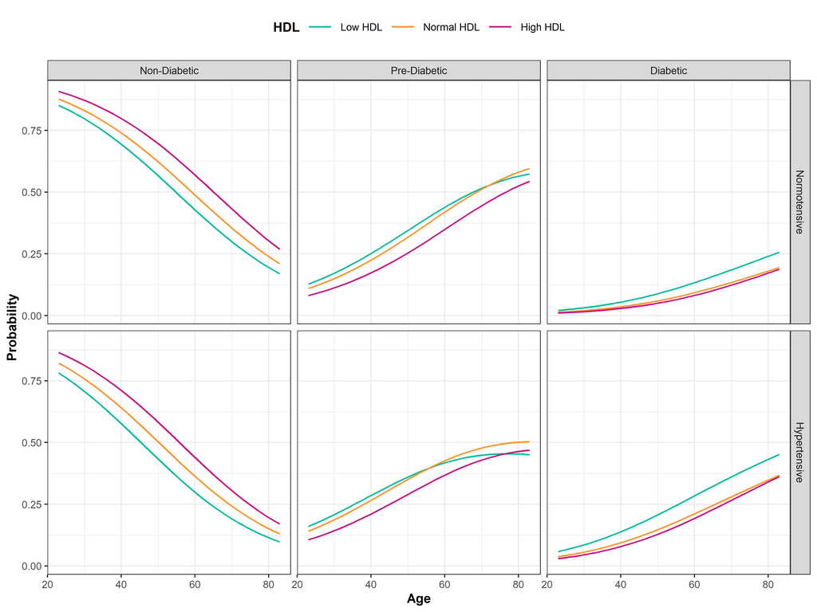

```r
weightMedian = median(JHS3$weight)
ageMin = ceiling(min(JHS3$age))
ageMax = floor(max(JHS3$age))
ageN = length(ageMin:ageMax)

simData <- data.frame(HTN = rep(c("Normotensive", "Hypertensive"), each = 3*ageN),
                      HDL = rep(rep(c("Low","Normal","High"), 2), each = ageN),
                      age = rep(ageMin:ageMax, 6),
                      weight = rep(weightMedian, 6*ageN))

simData <- cbind(simData, predict(m3, newdata = simData, type = "probs"))

simData <- simData %>%
  mutate(HDL = ifelse(HDL=="Low", "Low HDL", ifelse(HDL=="Normal", "Normal HDL", "High HDL"))) %>%
  mutate(HDL = factor(HDL, levels = c("Low HDL","Normal HDL","High HDL")),
         HTN = factor(HTN, levels = c("Normotensive","Hypertensive"))) %>%
  group_by(HTN, HDL) %>%
  pivot_longer(cols = c("Non-Diabetic","Pre-Diabetic","Diabetic"), names_to = "Diabetes", values_to = "Probability") %>%
  mutate(Diabetes = factor(Diabetes, levels = c("Non-Diabetic","Pre-Diabetic","Diabetic")))

  ggplot(simData, aes(x=age, y=Probability, color=HDL)) +
    scale_color_manual(values = c("#00BBA0","#FA962D","#C71585")) +
    geom_line() +
    labs(x = "Age", y = "Probability") +
    facet_grid(HTN ~ Diabetes) +
    theme_bw(base_size = 8) +
    theme(title=element_text(face="bold"), legend.position="top")
```

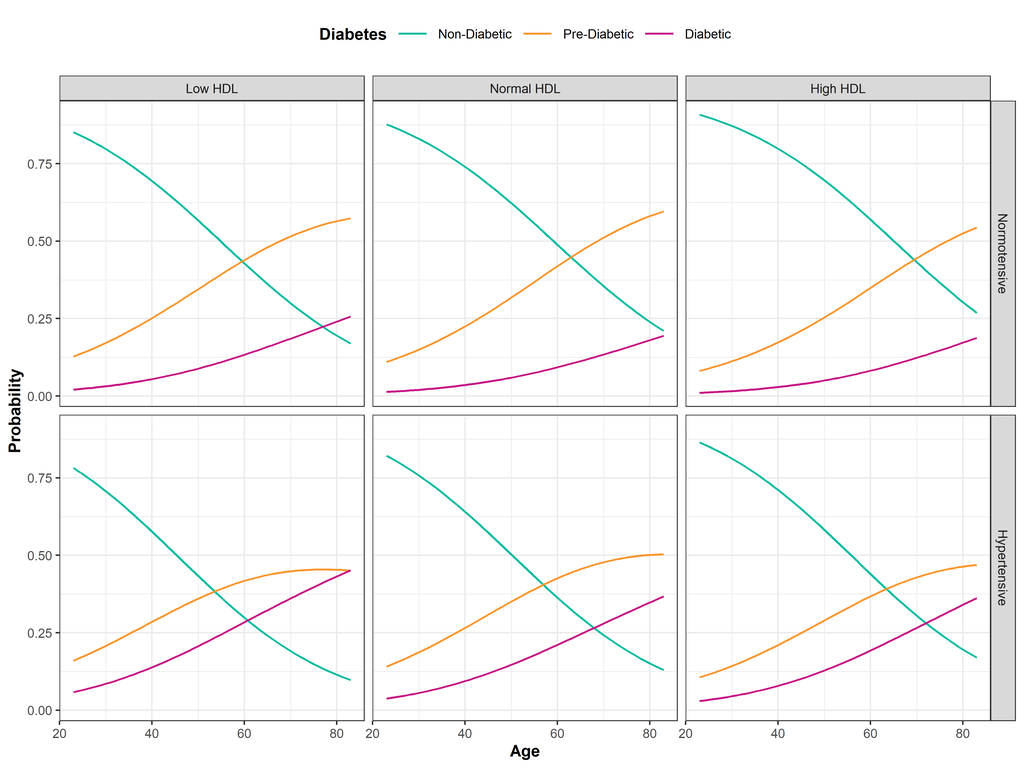

```r
  ggplot(simData, aes(x=age, y=Probability, color=Diabetes)) +
    scale_color_manual(values = c("#00BBA0","#FA962D","#C71585")) +
    geom_line() +
    labs(x = "Age", y = "Probability") +
    facet_grid(HTN ~ HDL) +
    theme_bw(base_size = 8) +
    theme(title=element_text(face="bold"), legend.position="top")
```

## 5

**Required for graduate students / extra credit for undergraduate students: Write a paragraph to summarize the analyses in this project, written such that a non-quantitative person could understand.**

Using the JHS data set we built several regression models using diabetic status as the outcome variable and for the predictor variables we used: age, weight, hypertension status, and fasting HDL categorization. 198 incomplete cases were omitted from analysis leaving the total number of observations to be 2455.

The first built was a binomial logistic regression model with interactions. In this model the outcome variable only has 2 levels, Non-Diabetic and Diabetic. We are modeling the affects that age, weight, HDL, HTN, and the interactions between weight and both HTN and HDL all have on the outcome variable. It was found that the predictor HDL does not have a significant affect on the outcome and neither does it’s interaction with weight.

The second built was an ordinal logistic regression model. In this model the outcome variable has 3 ordered levels: Non-Diabetic, Pre-Diabetic, and Diabetic. We are modeling the affects that age, weight, HDL, and HTN have on the outcome variable. To use this model, we needed to have meet the assumption of proportional odds but did not (described above in question 4).

The third built was a nominal logistic regression model. In this model the outcome variable has 3 NON-ordered levels: Non-Diabetic, Pre-Diabetic, and Diabetic. We are again modeling the affects that age, weight, HDL, and HTN have on the outcome variable. This regression produces 2 models. It was found that overall, all predictors have a significant affect on the outcome variable, but when looking at predictors by category and outcome level, all but 1 combination, Pre-Diabetic and Normal HDL, had a significant affect on the outcome. This model shows that, as compared to someone who is Normotensive, someone who is Hypertensive has a 206% increase in the odds of being Diabetic as compared to being Non-Diabetic. It also shows that, as compared to being Non-Diabetic, those with increased levels of HDL have decreased odds of Diabetes.